# PPOL670 | Applications in Supervised Machine Learning

Regression

Week 9

# Overview

In this notebook, we’ll apply the machine learning concepts covered in the supervised learning lecture on regession methods. Note that there are many libraries that can perform the methods that we reviewed in class, but we’ll focus here on using the `caret` package to perform these operations.

# Data

For this exercise, let’s examine some historical data of bike sharing in London downloaded from Kaggle. The data contains information on rider usage given a common set of climate and time predictors.

Assume we work for the company that runs the ride sharing venture: our aim is to build a model that best predicts the number of riders (`cnt`) at any given moment in time so that we can distribute resources appropriately. Please see the Kaggle site for a description of the variables: https://www.kaggle.com/hmavrodiev/london-bike-sharing-dataset#london_merged.csv

```r
dat = read_csv("london_bike_sharing.csv")
glimpse(dat)
```

```
## Observations: 17,414
## Variables: 10
## $ timestamp    <dttm> 2015-01-04 00:00:00, 2015-01-04 01:00:00, 2015-01-04 02…
## $ cnt          <dbl> 182, 138, 134, 72, 47, 46, 51, 75, 131, 301, 528, 727, 8…
## $ t1           <dbl> 3.0, 3.0, 2.5, 2.0, 2.0, 2.0, 1.0, 1.0, 1.5, 2.0, 3.0, 2…
## $ t2           <dbl> 2.0, 2.5, 2.5, 2.0, 0.0, 2.0, -1.0, -1.0, -1.0, -0.5, -0…
## $ hum          <dbl> 93.0, 93.0, 96.5, 100.0, 93.0, 93.0, 100.0, 100.0, 96.5,…
## $ wind_speed   <dbl> 6.0, 5.0, 0.0, 0.0, 6.5, 4.0, 7.0, 7.0, 8.0, 9.0, 12.0, …
## $ weather_code <dbl> 3, 1, 1, 1, 1, 1, 4, 4, 4, 3, 3, 3, 4, 3, 3, 3, 3, 3, 3,…
## $ is_holiday   <dbl> 0, 0, 0, 0, 0, 0, 0, 0, 0, 0, 0, 0, 0, 0, 0, 0, 0, 0, 0,…
## $ is_weekend   <dbl> 1, 1, 1, 1, 1, 1, 1, 1, 1, 1, 1, 1, 1, 1, 1, 1, 1, 1, 1,…
## $ season       <dbl> 3, 3, 3, 3, 3, 3, 3, 3, 3, 3, 3, 3, 3, 3, 3, 3, 3, 3, 3,…
```

# Split the Sample: Training and test data

Before event looking at the data, let’s split the sample up into a training and test dataset. We’ll completely hold off on viewing the test data, so as not to bias our development of the learning model.

```r
set.seed(123)
index = createDataPartition(dat$cnt,p=.8,list=F)
train_data = dat[index,] # Use 80% of the data as training data
test_data = dat[-index,] # holdout 20% as test data

dim(train_data)
```

```
## [1] 13933    10
```

```r
dim(test_data)
```

```
## [1] 3481   10
```

# Examine the Data

```r
summary(train_data)
```

```
##    timestamp                        cnt             t1              t2
##  Min.   :2015-01-04 00:00:00   Min.   :   0   Min.   :-1.50   Min.   :-6.00
##  1st Qu.:2015-07-05 03:00:00   1st Qu.: 257   1st Qu.: 8.00   1st Qu.: 6.00
##  Median :2016-01-03 14:00:00   Median : 844   Median :12.50   Median :12.50
##  Mean   :2016-01-04 12:58:23   Mean   :1144   Mean   :12.48   Mean   :11.54
##  3rd Qu.:2016-07-05 06:00:00   3rd Qu.:1672   3rd Qu.:16.00   3rd Qu.:16.00
##  Max.   :2017-01-03 23:00:00   Max.   :7860   Max.   :34.00   Max.   :34.00
##       hum           wind_speed     weather_code      is_holiday
##  Min.   : 20.50   Min.   : 0.00   Min.   : 1.000   Min.   :0.00000
##  1st Qu.: 63.00   1st Qu.:10.00   1st Qu.: 1.000   1st Qu.:0.00000
##  Median : 74.50   Median :15.00   Median : 2.000   Median :0.00000
##  Mean   : 72.37   Mean   :15.87   Mean   : 2.717   Mean   :0.02146
##  3rd Qu.: 83.00   3rd Qu.:20.50   3rd Qu.: 3.000   3rd Qu.:0.00000
##  Max.   :100.00   Max.   :56.50   Max.   :26.000   Max.   :1.00000
##    is_weekend         season
##  Min.   :0.0000   Min.   :0.000
##  1st Qu.:0.0000   1st Qu.:0.000
##  Median :0.0000   Median :1.000
##  Mean   :0.2832   Mean   :1.491
##  3rd Qu.:1.0000   3rd Qu.:2.000
##  Max.   :1.0000   Max.   :3.000
```

Let’s look at the temporal coverage: Looks like the data roughly covers a two year time span.

```r
dat %>%
  summarize(min_date = min(timestamp),
            max_date = max(timestamp))
```

```
## # A tibble: 1 x 2
##   min_date            max_date
##   <dttm>              <dttm>
## 1 2015-01-04 00:00:00 2017-01-03 23:00:00
```

Visualize the distribution for each variable.

First, let’s look at the numerical variables.

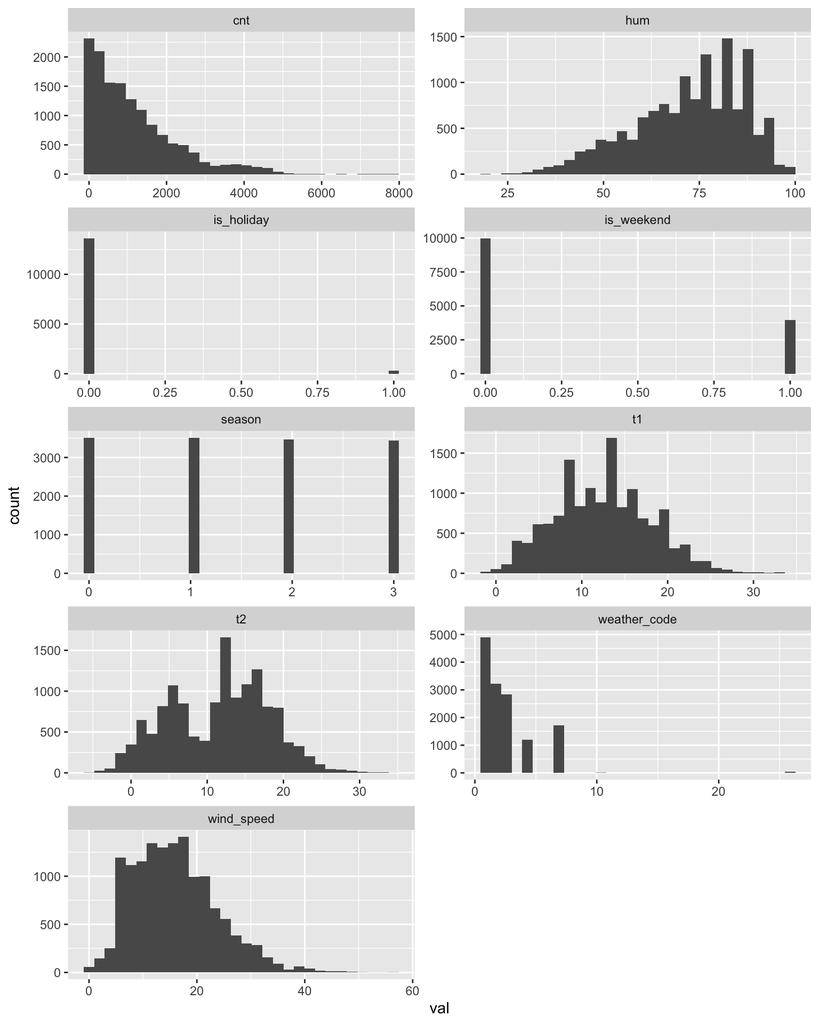

```r
train_data %>%
  select_if(is.numeric) %>%
  gather(var,val) %>% # equivalent to pivot_longer
  ggplot(aes(val,group=var)) +
  geom_histogram(bins = 30) +
  facet_wrap(~var,scales="free",ncol=2)
```

Most of the variables are continuous values. Some variables appear to be dummy (`is_weekend`) or ordered (`season`) variables. For the seasons, we may want to consider changing this variable to a dummy variable (where each season acts as a dummy variable) since the “order” in the seasons isn’t implied (i.e. winter isn’t necessarily worse than Fall, etc.).

Also, note that the weather code data is a bit of an enigma. There isn’t clear information online regarding what the code means, so we may want to drop it as we’re unsure about it.

It doesn’t appear that there is any missing data, so there is no need to impute any data.

```r
sum(is.na(train_data)) # any missingness??
```

```
## [1] 0
```

Finally, note that the outcome variable is a count, so we may want to log transform it so that it’s less skewed.

# Pre-process the Data

What do we need to do?

- Seasons variable to dummies
- Scale all the variables so that they fall into a 0 to 1 range.
- No need to impute missing values. All the data is there.

```r
# First, turn the season variable into a categorical variable
clean_steps = function(.data){
  .data %>%
  mutate(season = as.factor(season)) %>%
  select(-timestamp,-weather_code)
}

# Generate our recipe to preprocess the data
rcp <-
  recipe(cnt~.,data = train_data %>% clean_steps) %>%
  step_dummy(all_nominal(),-cnt) %>%

  # log the dependent variable so it's more normal, offset the count by 1 for instances when cnt==0
  step_log(cnt,offset=1) %>%

  step_range(all_numeric(),-cnt) %>%  # Normalize scale
  prep()


# Apply the recipe to the training and test data
train_data2 <- bake(rcp,train_data %>% clean_steps)
test_data2 <- bake(rcp,test_data%>% clean_steps) # Need to transform the seasons data here as well.
```

Let’s examine the post-processed data.

```r
train_data2 %>% glimpse()
```

```
## Observations: 13,933
## Variables: 10
## $ t1         <dbl> 0.12676056, 0.12676056, 0.11267606, 0.09859155, 0.09859155…
## $ t2         <dbl> 0.2000, 0.2125, 0.2125, 0.2000, 0.1500, 0.1250, 0.1250, 0.…
## $ hum        <dbl> 0.9119497, 0.9119497, 0.9559748, 1.0000000, 0.9119497, 1.0…
## $ wind_speed <dbl> 0.10619469, 0.08849558, 0.00000000, 0.00000000, 0.11504425…
## $ is_holiday <dbl> 0, 0, 0, 0, 0, 0, 0, 0, 0, 0, 0, 0, 0, 0, 0, 0, 0, 0, 0, 0…
## $ is_weekend <dbl> 1, 1, 1, 1, 1, 1, 1, 1, 1, 1, 1, 1, 1, 1, 1, 1, 1, 1, 1, 1…
## $ cnt        <dbl> 5.209486, 4.934474, 4.905275, 4.290459, 3.871201, 3.951244…
## $ season_X1  <dbl> 0, 0, 0, 0, 0, 0, 0, 0, 0, 0, 0, 0, 0, 0, 0, 0, 0, 0, 0, 0…
## $ season_X2  <dbl> 0, 0, 0, 0, 0, 0, 0, 0, 0, 0, 0, 0, 0, 0, 0, 0, 0, 0, 0, 0…
## $ season_X3  <dbl> 1, 1, 1, 1, 1, 1, 1, 1, 1, 1, 1, 1, 1, 1, 1, 1, 1, 1, 1, 1…
```

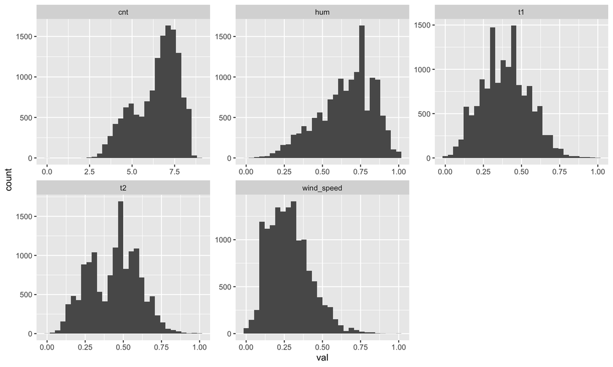

```r
train_data2 %>%
  select(cnt,hum,wind_speed,t1,t2) %>%
  gather(var,val) %>%
  ggplot(aes(val,group=var)) +
  geom_histogram(bins = 30) +
  facet_wrap(~var,scales="free",ncol=3)
```

# Cross-validation

When comparing different machine learning models, we want to make sure we’re making a fair and equal comparison. One way that random chance can sneak into our assessments of model fit is through cross-validation. We want to make sure that we’re cross-validating the data on the *exact same data partitions*.

`caret` makes this ease to do. Let’s use the k-fold cross-validation method with 10 folds in the data.

```r
set.seed(1988) # set a seed for replication purposes

folds <- createFolds(train_data2$cnt, k = 10) # Partition the data into 10 equal folds

sapply(folds,length)
```

```
## Fold01 Fold02 Fold03 Fold04 Fold05 Fold06 Fold07 Fold08 Fold09 Fold10
##   1392   1394   1394   1392   1393   1393   1392   1393   1396   1394
```

Now, let’s use the `trainControl()` function from `caret` to set up our validation conditions

```r
control_conditions <-
  trainControl(method='cv', # K-fold cross validation
               index = folds # The indices for our folds (so they are always the same)
  )
```

We’ll now use this same cross-validation object for everything that we do.

# Models

Let’s explore the different models that we covered in the lecture using the same package framework. As we saw last time in class, `caret` facilitates this task nicely.

## Linear Regression

```r
mod_lm <-
  train(cnt ~ .,          # Equation (outcome and everything else)
        data=train_data2, # Training data
        method = "lm",    # linear model
        metric = "RMSE",   # mean squared error
        trControl = control_conditions # Cross validation conditions
  )
```

Let’s look at the performance plots. What do we see?

```r
mod_lm
```

```
## Linear Regression
##
## 13933 samples
##     9 predictor
##
## No pre-processing
## Resampling: Cross-Validated (10 fold)
## Summary of sample sizes: 1392, 1394, 1394, 1392, 1393, 1393, ...
## Resampling results:
##
##   RMSE      Rsquared   MAE
##   1.085763  0.2840821  0.8474261
##
## Tuning parameter 'intercept' was held constant at a value of TRUE
```

## K-Nearest Neighbors

> Remember: these algorithms are computationally demanding, so they can take a little time to run depending on the power of your machine

```r
mod_knn <-
  train(cnt ~ .,           # Equation (outcome and everything else)
        data=train_data2,  # Training data
        method = "knn",    # K-Nearest Neighbors Algorithm
        metric = "RMSE",   # mean squared error
        trControl = control_conditions # Cross validation conditions
  )
```

Let’s look at the performance plots. What do we see?

```r
mod_knn
```

```
## k-Nearest Neighbors
##
## 13933 samples
##     9 predictor
##
## No pre-processing
## Resampling: Cross-Validated (10 fold)
## Summary of sample sizes: 1392, 1394, 1394, 1392, 1393, 1393, ...
## Resampling results across tuning parameters:
##
##   k  RMSE      Rsquared   MAE
##   5  1.153631  0.2236362  0.8749028
##   7  1.131674  0.2376629  0.8620692
##   9  1.120532  0.2455609  0.8568210
##
## RMSE was used to select the optimal model using the smallest value.
## The final value used for the model was k = 9.
```

- `caret` has default settings that auto explore different tunning parameters for the model.
- We can easily plot these tuning features using the standard plot functions (these function have been over-ridden in R)

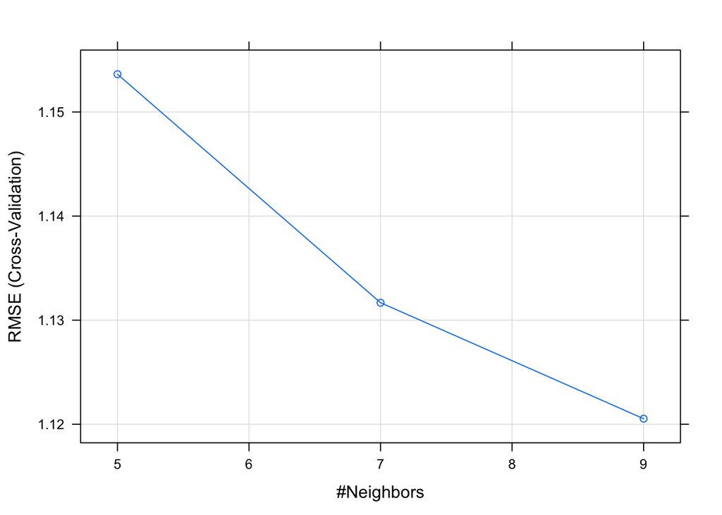

```r
plot(mod_knn)
```

```r
# Draw out the best model (the one with the best performance)
mod_knn$finalModel
```

```
## 9-nearest neighbor regression model
```

Now, let’s say we wanted to adjust the tunning parameters. We can explore different model tunings by using the `tuneGrid` argument.

```r
# Different values of the tuning parameter that I want to try.
knn_tune = expand.grid(k = c(1,3,10,50))

mod_knn <-
  train(cnt ~ .,           # Equation (outcome and everything else)
        data=train_data2,  # Training data
        method = "knn",    # K-Nearest Neighbors Algorithm
        metric = "RMSE",   # mean squared error
        trControl = control_conditions, # Cross validation conditions
        tuneGrid = knn_tune # Vary the tuning parameter K
  )
```

Look at performance: it doesn’t look that we get much of a boost when going all the way to K-Neighbors.

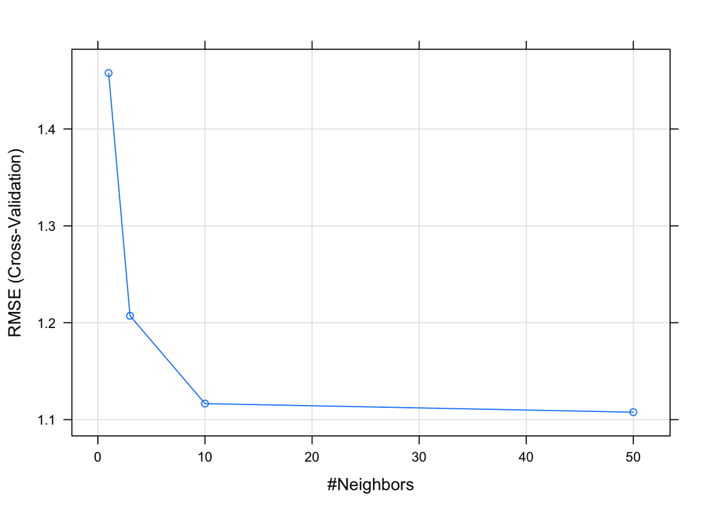

```r
plot(mod_knn)
```

## Classification and Regression Trees (CART)

```r
mod_cart <-
   train(cnt ~ .,            # Equation (outcome and everything else)
        data=train_data2,    # Training data
        method = "rpart",    # Regression tree
        metric = "RMSE",     # mean squared error
        trControl = control_conditions # Cross validation conditions
  )
```

```r
mod_cart
```

```
## CART
##
## 13933 samples
##     9 predictor
##
## No pre-processing
## Resampling: Cross-Validated (10 fold)
## Summary of sample sizes: 1392, 1394, 1394, 1392, 1393, 1393, ...
## Resampling results across tuning parameters:
##
##   cp          RMSE      Rsquared   MAE
##   0.01460431  1.133148  0.2207700  0.8942647
##   0.03061369  1.148022  0.1997074  0.9091909
##   0.18534633  1.187456  0.1779552  0.9513753
##
## RMSE was used to select the optimal model using the smallest value.
## The final value used for the model was cp = 0.01460431.
```

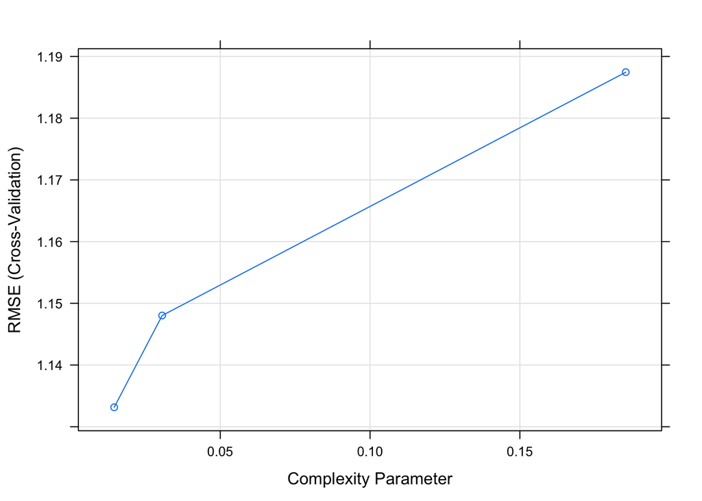

```r
plot(mod_cart)
```

Let’s visualize the tree we just grew. It looks like the humidity level is an important factor when predicting othe number of riders.

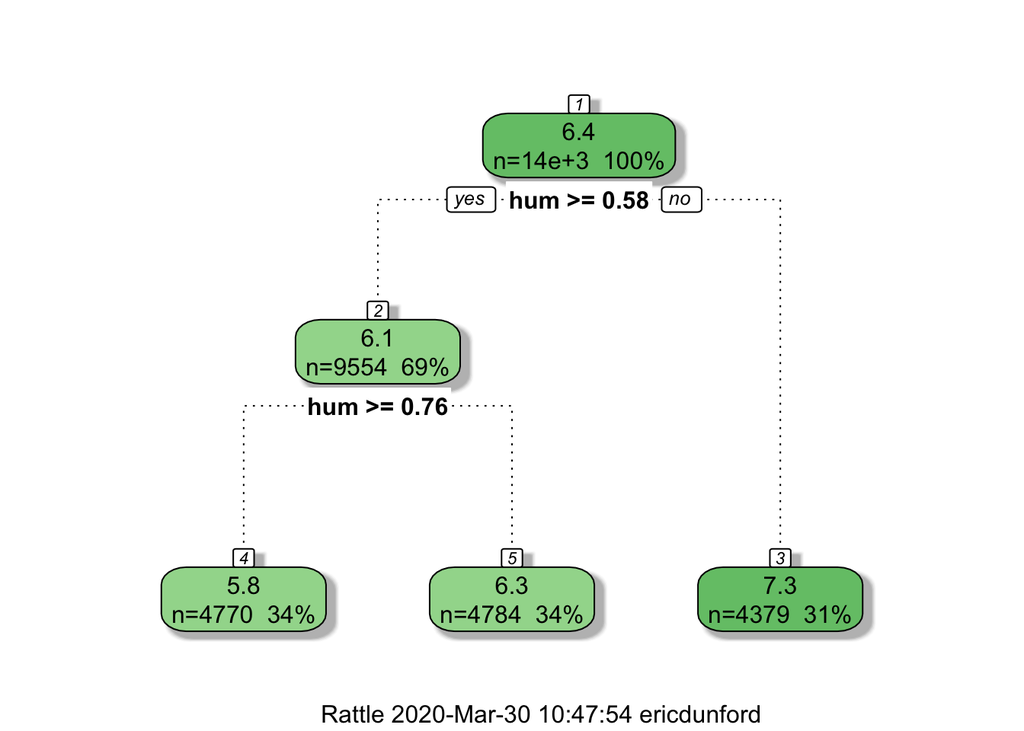

```r
# This tree goes really deep
fancyRpartPlot(mod_cart$finalModel)
```

We can actually print out the larger decision tree to look at it as a print out.

```r
print(mod_cart$finalModel)
```

```
## n= 13933
##
## node), split, n, deviance, yval
##       * denotes terminal node
##
## 1) root 13933 22920.760 6.440768
##   2) hum>=0.581761 9554 15849.020 6.066933
##     4) hum>=0.7578616 4770  7843.494 5.795529 *
##     5) hum< 0.7578616 4784  7303.837 6.337543 *
##   3) hum< 0.581761 4379  2823.460 7.256390 *
```

Let’s free the CART to grow deeper.

```r
tune_cart <- expand.grid(cp = c(0.0010281)) # Complexity Parameter (how "deep" our trees should grow)
mod_cart2 <-
  train(cnt ~ ., # Equation (outcome and everything else)
        data=train_data2, # Training data
        method = "rpart", # Classification Tree
        metric = "RMSE",     # mean squared error
        tuneGrid = tune_cart, # Tuning parameters
        trControl = control_conditions
  )
```

Doesn’t doo a whole lot better on out of sample data.

```r
print(mod_cart2)
```

```
## CART
##
## 13933 samples
##     9 predictor
##
## No pre-processing
## Resampling: Cross-Validated (10 fold)
## Summary of sample sizes: 1392, 1394, 1394, 1392, 1393, 1393, ...
## Resampling results:
##
##   RMSE      Rsquared   MAE
##   1.176862  0.2090636  0.8959772
##
## Tuning parameter 'cp' was held constant at a value of 0.0010281
```

Let’s look at the tree itself: much deeper!

```r
print(mod_cart2$finalModel)
```

```
## n= 13933
##
## node), split, n, deviance, yval
##       * denotes terminal node
##
##   1) root 13933 22920.76000 6.440768
##     2) hum>=0.581761 9554 15849.02000 6.066933
##       4) hum>=0.7578616 4770  7843.49400 5.795529
##         8) t2< 0.31875 1734  3052.30600 5.493743
##          16) t1< 0.0915493 136   294.57460 4.929792
##            32) t2>=0.08125 105   179.95430 4.678887 *
##            33) t2< 0.08125 31    85.62117 5.779631 *
##          17) t1>=0.0915493 1598  2710.79700 5.541739
##            34) season_X3< 0.5 692  1238.81400 5.334681 *
##            35) season_X3>=0.5 906  1419.65400 5.699889 *
##         9) t2>=0.31875 3036  4543.06600 5.967893
##          18) hum>=0.827044 1605  2414.32900 5.844749
##            36) season_X3< 0.5 1273  1899.03600 5.782296
##              72) season_X2< 0.5 561   769.49760 5.577141
##               144) t2< 0.55625 455   566.41170 5.439041
##                 288) wind_speed< 0.2787611 319   390.94830 5.279727 *
##                 289) wind_speed>=0.2787611 136   148.37560 5.812728 *
##               145) t2>=0.55625 106   157.16060 6.169926 *
##              73) season_X2>=0.5 712  1087.32200 5.943942 *
##            37) season_X3>=0.5 332   491.28980 6.084215
##              74) wind_speed>=0.340708 70   102.06880 5.520678 *
##              75) wind_speed< 0.340708 262   361.05150 6.234778 *
##          19) hum< 0.827044 1431  2077.09900 6.106012 *
##       5) hum< 0.7578616 4784  7303.83700 6.337543
##        10) t2< 0.43125 2100  3522.68900 6.083234
##          20) hum>=0.6823899 1034  1785.67900 5.902701
##            40) t2< 0.20625 270   530.79860 5.568773 *
##            41) t2>=0.20625 764  1214.13400 6.020712 *
##          21) hum< 0.6823899 1066  1670.62100 6.258348
##            42) season_X1>=0.5 20    25.17908 5.144182 *
##            43) season_X1< 0.5 1046  1620.14000 6.279651
##              86) is_weekend>=0.5 279   244.85280 6.070290
##               172) t2< 0.16875 24    10.17090 4.910151 *
##               173) t2>=0.16875 255   199.33960 6.179480 *
##              87) is_weekend< 0.5 767  1358.61000 6.355807 *
```

[output cut: 9 more lines]

```
##              93) wind_speed>=0.1371681 265   242.79050 6.763907 *
##            47) hum< 0.6792453 327   249.89310 7.062253 *
##     3) hum< 0.581761 4379  2823.46000 7.256390
##       6) t1< 0.556338 2849  2093.33600 7.053777
##        12) hum>=0.4685535 1575  1508.43900 6.830772
##          24) season_X2< 0.5 1207  1246.40700 6.729832
##            48) hum>=0.5503145 348   442.56280 6.460416 *
##            49) hum< 0.5503145 859   768.35160 6.838978 *
##          25) season_X2>=0.5 368   209.39760 7.161846 *
##        13) hum< 0.4685535 1274   409.73740 7.329470
##          26) t2< 0.44375 430   144.44380 7.086803 *
##          27) t2>=0.44375 844   227.07120 7.453104 *
##       7) t1>=0.556338 1530   395.38250 7.633674
##        14) hum>=0.4433962 565   195.29420 7.429494 *
##        15) hum< 0.4433962 965   162.74290 7.753220 *
```

## Random Forest

```r
mod_rf <-
  train(cnt ~ ., # Equation (outcome and everything else)
        data=train_data2, # Training data
        method = "ranger", # random forest (ranger is much faster than rf)
        metric = "RMSE",     # mean squared error
        trControl = control_conditions
  )
```

There are three tunning parameters in this model:

```r
mod_rf
```

```
## Random Forest
##
## 13933 samples
##     9 predictor
##
## No pre-processing
## Resampling: Cross-Validated (10 fold)
## Summary of sample sizes: 1392, 1394, 1394, 1392, 1393, 1393, ...
## Resampling results across tuning parameters:
##
##   mtry  splitrule   RMSE      Rsquared   MAE
##   2     variance    1.079403  0.2928344  0.8310103
##   2     extratrees  1.089664  0.2943175  0.8483801
##   5     variance    1.110689  0.2624444  0.8471875
##   5     extratrees  1.092182  0.2793585  0.8318875
##   9     variance    1.120489  0.2538021  0.8546560
##   9     extratrees  1.103805  0.2694784  0.8386053
##
## Tuning parameter 'min.node.size' was held constant at a value of 5
## RMSE was used to select the optimal model using the smallest value.
## The final values used for the model were mtry = 2, splitrule = variance
##  and min.node.size = 5.
```

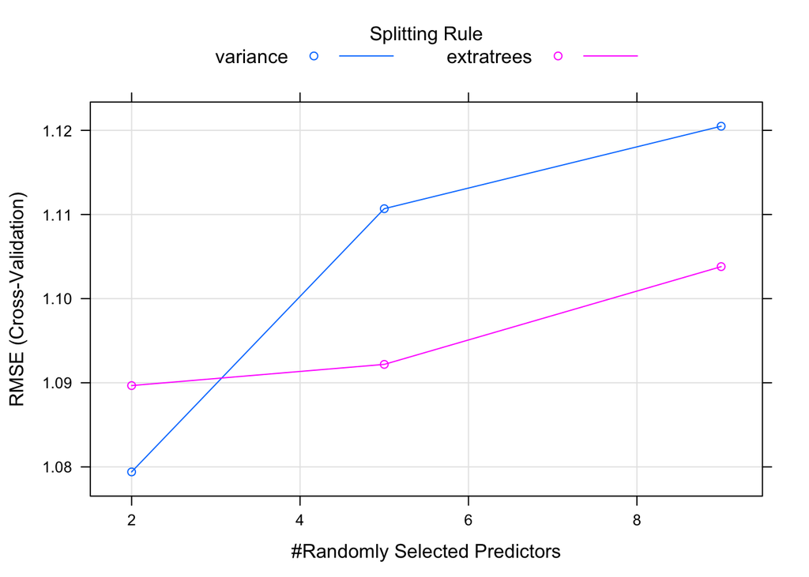

```r
plot(mod_rf)
```

```r
mod_rf$bestTune
```

```
##   mtry splitrule min.node.size
## 1    2  variance             5
```

# Model Comparison

How did the different methods perform? Which one did the best?

```r
# Organize all model imputs as a list.
mod_list <-
  list(
    lm = mod_lm,
    knn = mod_knn,
    cart = mod_cart,
    cart_deep = mod_cart2,
    rf = mod_rf
  )

# Resamples allows us to compare model output
resamples(mod_list)
```

```
##
## Call:
## resamples.default(x = mod_list)
##
## Models: lm, knn, cart, cart_deep, rf
## Number of resamples: 10
## Performance metrics: MAE, RMSE, Rsquared
## Time estimates for: everything, final model fit
```

Examine the error across each of the models.

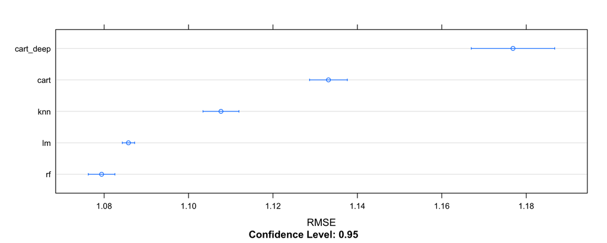

```r
dotplot(resamples(mod_list),metric = "RMSE")
```

Examine the fit across each of the models.

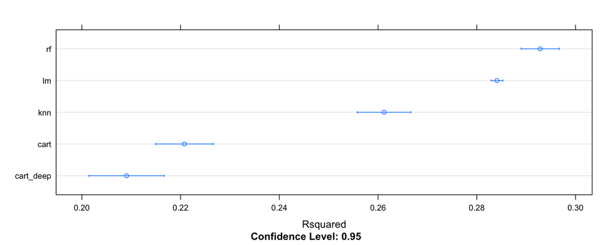

```r
dotplot(resamples(mod_list),metric = "Rsquared")
```

# Test the Predictive Accuracy of the Best Model

Of the models we ran, it looks like the Random Forest model did the best. Let’s now see how well it does on predicting the test data.

```r
pred <- predict(mod_rf,newdata = test_data2)
mse = sum((test_data2$cnt-pred)^2)/nrow(test_data2)
mse
```

```
## [1] 1.056571
```

We can also use the metrics package to calculate performance metrics.

```r
# If the package isn't installed on your machine
# install.packages("Metrics")

pred <- predict(mod_rf,newdata = test_data2)

# Mean squared error
Metrics::mse(actual=test_data2$cnt,predicted = pred)
```

```
## [1] 1.056571
```